# Assignment 7

2024-03-25

## # Part 1: Neural Networks

Neural networks are the state of the art for prediction tasks. Countless businesses and organizations use them, and they are becoming widespread in the justice system. Check out [this paper](https://www.frontiersin.org/articles/10.3389/fpsyg.2021.587943/full) for a decent review of neural networks applied to criminal justice tasks.

In this lab we’ll explore some “simple” neural networks. Packages like `keras` and `tensorflow` are very flexible, allow for a lot of control over network architecture, and are widely used professionally. They’re also difficult to learn and set up. Several simpler packages are available in R, but they vary in customization versus ease of use. For example, `nnet` allows for a single hidden layer. `neuralnet` allows for multiple hidden layers, but is somewhat buggy and it’s difficult to assess model performance.

Below, load up the packages we’ll use. Run `install.packages(c('nnet','NeuralNetTools','gridExtra'))` in the Console before you run the chunk below. The `nnet` library contains the functions for constructing and training neural network models, and `NeuralNetTools` contains several useful functions for inspecting their properties. Get the `gridExtra` package also – it is useful for arranging ggplots.

```r
library(nnet)
library(NeuralNetTools)
library(ggplot2)
library(gridExtra)
```

Let’s start practicing neural networks in R on a simple and familiar data set. Then, we’ll tackle one that’s more complicated, yet interesting. Run the chunk below to get the `iris` data into your environment.

```r
data('iris')
head(iris)
```

```
##   Sepal.Length Sepal.Width Petal.Length Petal.Width Species
## 1          5.1         3.5          1.4         0.2  setosa
## 2          4.9         3.0          1.4         0.2  setosa
## 3          4.7         3.2          1.3         0.2  setosa
## 4          4.6         3.1          1.5         0.2  setosa
## 5          5.0         3.6          1.4         0.2  setosa
## 6          5.4         3.9          1.7         0.4  setosa
```

**Inspect the `iris` dataset - how many rows and columns are there? What does each row represent? (I know it’s annoying that I ask this on every HW, but soon you’ll be on your own - this should always be the FIRST question you ask yourself when you load up a new dataset!!)**

— Your answer here —

**Make 2 ggplots below, stored in the variables `p1` and `p2`.** By storing them in variables, we can pass them into `grid.arrange()` from `gridExtra` to plot them side-by-side. In `p1`, plot `Petal.Length` on the x-axis and `Petal.Width` on the y-axis, and set `color = Species` in `aes()`. In `p2`, plot `Sepal.Length` on x and `Sepal.Width` on y, again setting `color = Species`. Add a `geom_point()` layer to each. I’ve done a little extra formatting to keep a single legend within the second plot.

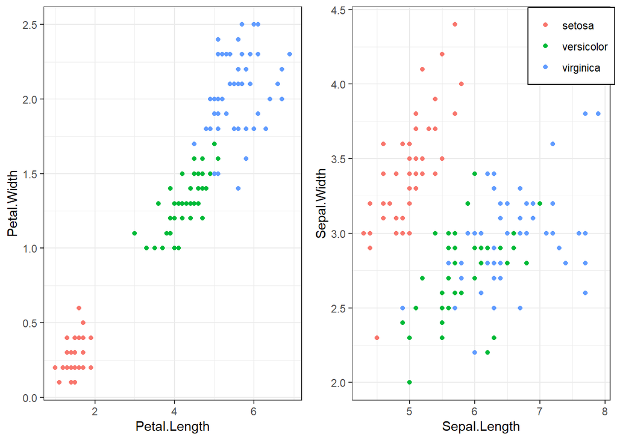

```r
# Plot of petal length by width, colored by species
p1 = ggplot(iris) +
  aes(x = Petal.Length, y = Petal.Width, color = Species) +
  geom_point() +
  theme_bw() +
  theme(legend.position = 'none')

# Plot of sepal length by width, colored by species
p2 = ggplot(iris) +
  aes(x = Sepal.Length, y = Sepal.Width, color = Species) +
  geom_point() +
  theme_bw() +
  theme(legend.position = c(0.85, 0.9),
        legend.title = element_blank(),
        legend.background = element_rect(fill = 'white', linetype = 'solid',
                                         color = 'black', linewidth = 0.5))
# Arrange the two plots side-by-side
grid.arrange(p1, p2, ncol = 2)
```

**Based on the plots above, do you think any of the variables will be more useful than others for classifying species? Why or why not?**

— Your answer here —

Unlike random forests, neural networks are sensitive to the scale of the input data. Consider training a model that has variables `Household Income` and `Number of Children`. The income variable has values likely in the 10,000s, whereas number of children may range from 0-5. For many algorithms, large values can “dominate” small values, so a common practice is to rescale each variable to be on a common scale. Some popular rescalings for neural networks are:

- Scale each column to range from 0 to 1
- Scale each column to range from -1 to 1
- Scale each column such that the standard deviation is 1, and center the data so the mean is 0 (z-scoring or “whitening”)

If you’re interested, there’s good reading about rescaling [here](https://machinelearningmastery.com/how-to-improve-neural-network-stability-and-modeling-performance-with-data-scaling/).

Below is code that rescales each input to range from 0 to 1. The `apply()` function is useful for applying a function to each column of a dataframe (here, we do `min` and `max`). And the `scale()` function will take care of rescaling. **Run the chunk below to rescale each input column to 0-1.**

```r
mins = apply(iris[,1:4], 2, min) # Get the minimum value of each column
maxs = apply(iris[,1:4], 2, max) # Get the maximum value of each column

# Apply the re-scaling to the first four columns
iris[,1:4] = scale(iris[,1:4], center = mins, scale = maxs - mins)
```

Almost ready to model – first let’s split into a train and test set. Using the `sample()` function, **split the data into 70% for training, and 30% for testing.** Store the training data into a variable called `train` and the testing data into a variable called `test`. I haven’t had you do this on your own yet, so play around with `sample()` first, and read the docs using `?sample`. If you get stuck, check the `A7_hints.txt` file for the answer.

IMO, the best way to do this is to select 70% of the rows at random using `logical indexing`. So you’d have 70% of the total number of rows (150 here, 70% would be 105) be randomly labeled with `TRUE` and the rest as `FALSE`. You could then use that list of `TRUE` and `FALSE` as an `index` into the original dataframe.

And, because we will begin introducing randomness into our processes going forward, let’s “seed” `R`’s random number generator. Google “seed random number generator” to learn more, but the effect is that you’ll use the same “random” numbers each time you, or anyone else, runs your code. This makes your work *reproducible*. (Unfortunately this doesn’t work so great in R Markdown – but it’s good practice to get into the habit)

```r
# Seed the random number generator for reproducibility
set.seed(123)

# Split the data 70-30 into training and testing sets
idx = sample(c(TRUE,FALSE), size = nrow(iris), replace = TRUE, prob = c(70,30)) # see if you can fill in the missing arguments

train = iris[idx, ] # see if you can use 'idx' to get the correct subsets here
test = iris[!idx, ]
```

We have one more problem – take a look at the training data frame by clicking on it in your environment. Consider that we’ll be feeding each data row into the neural network one at a time, in order. And remember that the “goal” of the neural network is to update its predictions based on what it’s seen in the past… **Do you think that the order in which the `Species` appear might influence the model’s predictions? Why or why not?**

— Your answer here —

We can solve this problem using `sample()` again (it’s a VERY useful function!). **Study the code below before you run it, and tell me what you think it accomplishes.** After you run it, take another look at `train`.

— Your answer here —

```r
train = train[sample(1:nrow(train)), ]
```

OK, after a bit of wrangling we are ready to model! Like we saw with `randomForest()`, making the model is a one-liner. The vast majority of data science programming labor is pre-processing the data! The basic format for the `nnet()` function is below. The first argument is a formula. Read it like `Y ~ X`, where `Y` is the response/outcome variable we are trying to predict, and `X` is/are the input variables used to make the prediction (formally called “predictor” or “explanatory” variables). The `.` in place of `X` means “all variables except the `Y` variable”. **Run the chunk below.** It might take a minute or two depending on your computer’s processing power. (The `size` argument is the number of neurons in the hidden layer - again `nnet` only allows for a single hidden layer).

```r
nn = nnet(Species ~ ., data = train, size = 5)
```

[output not shown]

You should see some output from R on the model’s learning process as it iterates over the training data. The `value` here is not quite the same as the error rate. Instead, this is the value of the *cost function*. **Does the cost function value go up, down, or no change, over the course of training? Does that indicate that the model is getting better or worse at fitting the training data?**

— Your answer here —

Unlike with `randomForest()`, `nnet()` does not provide a measure of accuracy/error that’s easily interpretable out-of-the-box. Instead, we’ll have to compute performance metrics ourselves. Below is a code chunk that evaluates the model’s accuracy on the *training* data. We can use this to get a sense of how well the model predicts data it’s already seen. First, it makes predictions on the training classes using `predict()` on only the input variables (columns 1:4), and stores the predictions in `preds`. Then, it stores the true class labels in `truth`. Then it computes accuracy as the proportion of predicted classes that match the true classes. Finally it organizes the predictions and true classes into a confusion matrix. **Run the chunk below and inspect the output.**

```r
# Get error on training (seen before) data
preds = predict(nn, train[,1:4], type = 'class') # Predictions come out as characters
truth = as.character(train[,5]) # Convert species column to character type

cat('Accuracy: ', sum(truth == preds) / length(truth), '\n', # Compute accuracy
    '\nConfusion matrix: \n')
```

```
## Accuracy:  1
##
## Confusion matrix:
```

```r
table(truth, preds) # Create confusion matrix
```

```
##             preds
## truth        setosa versicolor virginica
##   setosa         35          0         0
##   versicolor      0         36         0
##   virginica       0          0        35
```

**What was the model’s accuracy on the training data? Did any classes cause confusion? If so, which ones?** Don’t be surprised if your neural network performs extremely well on the training data.

— Your answer here —

The real measure of performance is accuracy on the *testing*, or held-out, data that the model has never seen. **Below, compute the accuracy, and make a confusion matrix for the testing data.** (Hint: just copy+paste the chunk above, and substitute `test` anywhere you have `train`)

```r
# Get predictions on testing (unseen) data
preds = predict(nn, test[,1:4], type = 'class') # Predictions come out as characters
truth = as.character(test[,5]) # Convert species column to character type

cat('Accuracy: ', sum(truth == preds) / length(truth), '\n', # Compute accuracy
    '\nConfusion matrix: \n')
```

```
## Accuracy:  0.9090909
##
## Confusion matrix:
```

```r
table(truth, preds) # Create confusion matrix
```

```
##             preds
## truth        setosa versicolor virginica
##   setosa         15          0         0
##   versicolor      0         11         3
##   virginica       0          1        14
```

**How did your model perform on the testing data compared to the training set? What’s the accuracy, and did any classes cause the model some trouble? Based on your ggplot above, does this confusion make sense?**

— Your answer here —

Neural networks are notorious for being “black boxes”. Meaning, they can make highly accurate predictions, but we don’t know WHY they make the decisions they do. The reason they are hard to interpret is the sheer number of parameters (weights) involved, which in deep networks can reach into the tens of thousands. **Run the line below to print a brief summary of your network model.**

```r
print(nn)
```

```
## a 4-5-3 network with 43 weights
## inputs: Sepal.Length Sepal.Width Petal.Length Petal.Width
## output(s): Species
## options were - softmax modelling
```

**How many parameters (i.e. weights) does your network have?**

— Your answer here —

Despite the complexity of neural networks models, some argue that they are not necessarily as opaque as they are made out to be. The `NeuralNetTools` package by Marcus Beck has several functions to inspect our network models. **Start by visualizing your model, by running the line below.** The `bias = FALSE` turns off the bias weights display, as we’re not that interested in those, and the `pad_x` argument controls the width of the plot - you might play with it if some text is cropped off on your display.

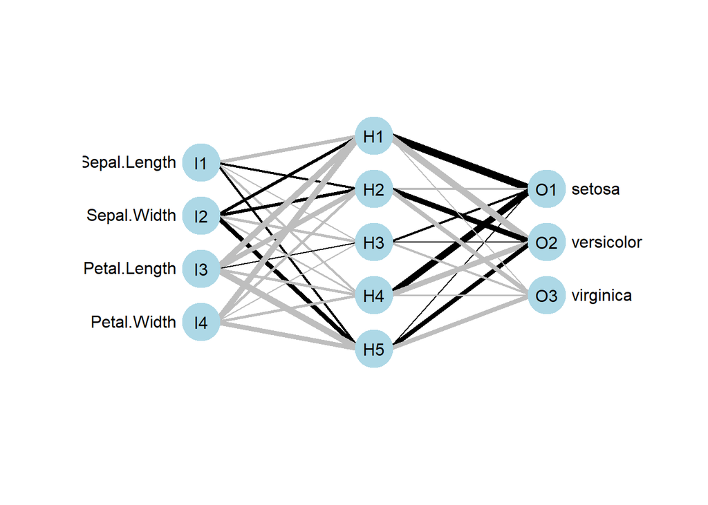

```r
plotnet(nn, bias = FALSE, pad_x = 0.8)
```

The black connections are positive, meaning they increase the activation function of the connected neuron. Gray connections are negative, meaning they suppress the neuron (i.e. decrease the activation function). The thickness of each line represents the magnitude of each weight (high weights more strongly influence activation). **Does the plot reflect the model structure you saw in your call to `print(nn)` above (in terms of layers, number of neurons per layer)? Does anything about the plot stand out as informative about how the model makes predictions based on the input data? (A perfectly reasonable answer is: “no, it still makes no sense”, but study it and feel free to speculate).**

— Your answer here —

Beck’s package also implements a measure of variable importance, just like we saw with `randomForest()`. [His blog post](https://beckmw.wordpress.com/2013/08/12/variable-importance-in-neural-networks/) is well worth the read if you’re interested. The `NeuralNetTools` function `garson()` implements a measure of variable importance proposed by Garson in 1991 (hence the function name). However, Garson’s algorithm only works if the network has a single hidden layer (ours does) and *has a single output neuron* (ours has 3). Below is some code to restructure the data so that the `Species` column takes on a numeric value from 0 to 1. Then we train a new network (on the full dataset, nevermind train/test split for now), and plot the resulting model. Run the chunk below to verify that this model outputs a single value corresponding to a species label.

```r
# Make a copy of the 'iris' data
single_output = iris
# Convert the factor values to integers (they'll go 1,2,3 corresponding to 'species')
species = as.numeric(single_output$Species)
# The scale() function with these arguments squeezes the 1,2,3 to the range of 0-1
species = scale(species, center = min(species), scale = max(species) - min(species))
# Overwrite the dataframe's Species columns to the new numeric representation
single_output$Species = species

# Train a new neural network
nn_single = nnet(Species ~ ., data = single_output, size = 5)
```

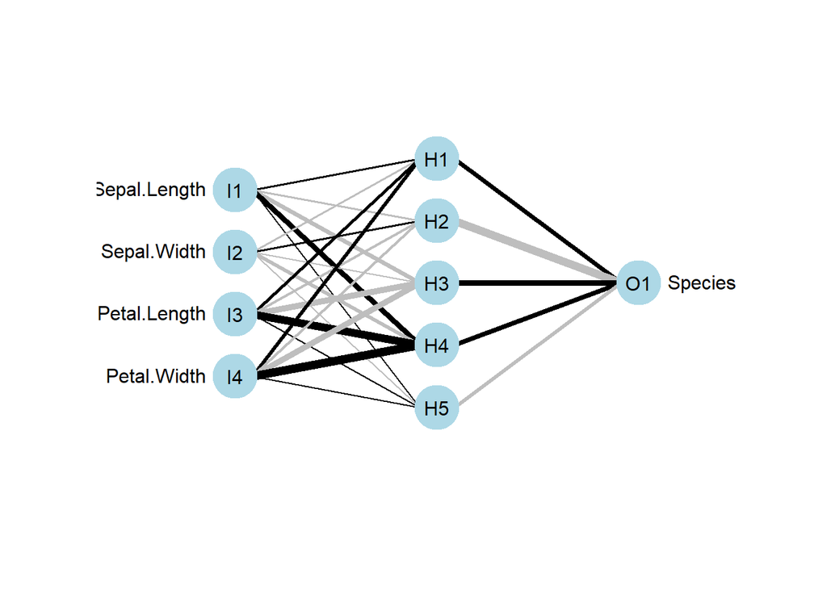

```r
# And plot it to confirm
plotnet(nn_single, bias = FALSE, pad_x = 0.8)
```

**How does this neural network differ from the one above (in terms of neurons, not connections/weights)?**

— Your answer here —

Now, we can use this new network to find the variables that were important to the model in discriminating the classes.

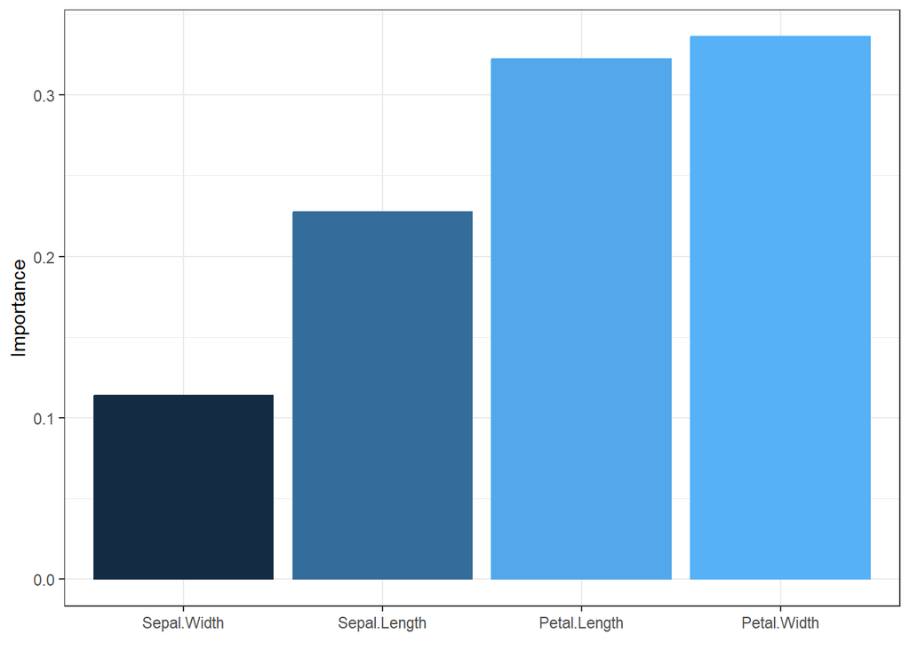

```r
garson(nn_single)
```

**Which variables were most important for predicting Species? Does this make sense given the ggplots you made at the beginning?** (Due to the randomness involved in weight initiation, it very well may NOT make sense!)

— Your answer here —

## # Part 2: Neural Networks and a real justice data set

Let’s wrap up by applying your new neural network skills to a real justice data set. Read in the file `NIJ_recidivism.csv` below. These data are from the [National Institute of Justice’s 2021 Recidivism Forecasting Challenge](https://nij.ojp.gov/funding/recidivism-forecasting-challenge). The raw data set contains 18,028 observations of 53 variables, with the goal of predicting recidivism (true/false) within 3 years of release from prison, from the period 2013-2015. Actual recidivism (true/false) for each person is known, so we can train a *supervised* model.

The NIJ’s page has a lot of information on this competition and submissions from the entrants. Models produced by individuals and teams were judged on two criteria. **Check out [this document](https://www.ojp.gov/pdffiles1/nij/304110.pdf), and read the Abstract on Page 3. What were the two “indices” used to score models?** (short answer! I just want you to see that you are already familiar with these criteria)

— Your answer here —

```r
# Read in the recidivism data set
recid = read.csv('NIJ_recidivism.csv')
recid$Recidivism_Within_3years = as.factor(recid$Recidivism_Within_3years)
```

The raw data needed a fair bit of wrangling and prep to feed into a neural network (and this assignment is already getting long!). I have already done this for you! For the curious – the raw data are in the Lab 7 Courseworks folder, along with a Markdown script with code to clean it – **you do not need to do this for the assignment**. The cleaned data are trimmed to 10,315 observations on 16 variables, each column scaled to 0-1, except the response variable `Recidivism_Within_3years`, which is a factor with levels `true` and `false`.

Ideally, a fair model will not base predictions on variables we believe are irrelevant to decision-making. What constitutes “irrelevant” will vary by the situation, which is why domain expertise is needed in any data science endeavor. In justice settings, we ought to strive for fairness by constructing models that are unbiased to qualities such as race or gender. We saw last time that this is complicated!

In this particular dataset, `Gender` was coded as `F` and `M`, and all rows with `F` contained missing data in some columns. We might imagine women are given a different assessment than are men (if someone knows the answer, let me know!). This is a **measurement bias** we unfortunately have no control over. For simplicity, the `Gender` column has been removed. `Race` is coded either `White` or `Black`, which I converted to 0 or 1 when cleaning. To ensure `Race` is treated by the model without bias, let’s check that the probabilities of getting a `true` outcome are roughly the same for each `Race`. Last time we saw this called **demographic/statistical parity.**

```r
# Check for "statistical parity" - get probability of outcome for each level of Race
r0_prob = sum(recid$Race == 0 & recid$Recidivism_Within_3years == 'true') / sum(recid$Race == 0)
r1_prob = sum(recid$Race == 1 & recid$Recidivism_Within_3years == 'true') / sum(recid$Race == 1)

# Parity is difference in probability of outcome between two groups
parity = abs(r0_prob - r1_prob)
parity * 100 # Express as a percentage
```

```
## [1] 1.963276
```

**What is the probability of each `Race` having a `true` outcome (i.e. they did recidivate in 3 years)? Inspect `r0_prob` and `r1_prob` to see the numbers. Is the difference small enough to suggest we can proceed with modeling?** (you be the judge of ‘small enough’)

— Your answer here —

Let’s go ahead and use the data to train a neural network to predict recidivism. I’ve included some additional parameters below that you might like to play with. `size` is the number of neurons in the hidden layer, `maxit` is the maximum number of iterations to train (generally we get better with each iteration), `decay` is the “learning rate”, or how quickly/slowly the model stops traversing the cost function gradient. Small values mean more exploring (the `1e-5` is shorthand for `1x10^-5` which is “shorthand” for `0.00001`).

```r
nn = nnet(Recidivism_Within_3years ~ ., data = recid,
          size = 10,
          maxit = 300,
          decay = 1e-5)
```

Let’s evaluate the model’s performance as we did above, by predicting the recidivism labels using the training data. Usually we’d do a train/test split, but this will suffice to get an idea of performance.

```r
# Get error on the training data
preds = predict(nn, recid[,1:15], type = 'class') # Predictions come out as characters
truth = as.character(recid[,16]) # Convert species column to character type

cat('Accuracy: ', sum(truth == preds) / length(truth), '\n',
    '\nConfusion matrix: \n')
```

```
## Accuracy:  0.7140087
##
## Confusion matrix:
```

```r
cf = table(truth, preds) # Create confusion matrix
cf
```

```
##        preds
## truth   false true
##   false  2254 1928
##   true   1022 5111
```

**What was the model’s overall accuracy? Do you think this is acceptable if we are using this model to predict a person’s risk of committing more crime?**

— Your answer here —

Look carefully at the upper right and lower left corners of the confusion matrix. These are where the model made mistakes – either someone was predicted to recidivate but did not (upper right; false positive), or actually did recidivate but was predicted not to (lower left; false negative). To check the false positive/negative error rates, we’ll need to compute them ourselves:

```r
# We stored the confusion matrix as a variable 'cf' in the chunk above
# so we can use it again here
false_pos_rate = cf[1,2] / (cf[1,1] + cf[1,2])
false_neg_rate = cf[2,1] / (cf[2,1] + cf[2,2])

print(paste('False positive rate: ', false_pos_rate))
```

```
## [1] "False positive rate:  0.461023433763749"
```

```r
print(paste('False negative rate: ', false_neg_rate))
```

```
## [1] "False negative rate:  0.1666394912767"
```

**Does your model make false positive and false negative mistakes at the same rate? Would you agree if I said this model over-predicts recidivism? Why or why not?**

— Your answer here —

Below, visualize your network with `plotnet`. All of the arguments are for visualization purposes - play around with them if it’s difficult to read on your screen.

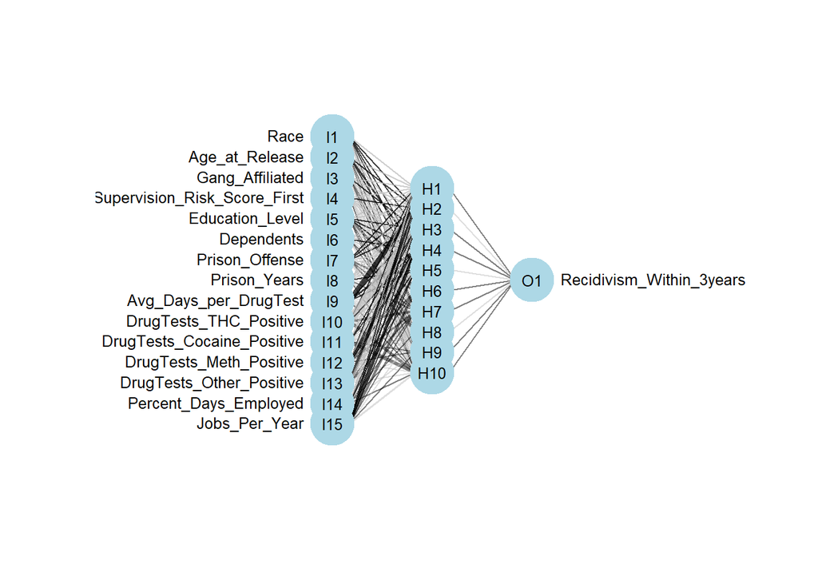

```r
plotnet(nn, bias = FALSE, alpha_val = 0.5, pad_x = 0.4,
        circle_cex = 5, cex_val = 0.8, max_sp = FALSE)
```

Finally, inspect variable importance using Garson’s method. The plot it returns is a ggplot, so it’s easy to customize. I’ve rotated the x-axis labels with `theme()` to make them easier to read.

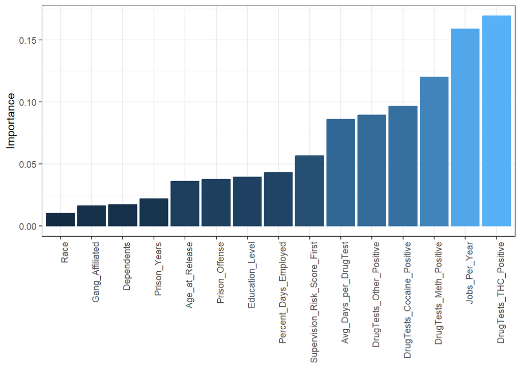

```r
garson(nn) +
  theme(axis.text.x = element_text(angle = 90, hjust = 1))
```

**Which variables stand out as most important to the neural network? Which variables stand out as LEAST important? Do any of these surprise you? How so? Does it appear that balancing outcomes for `Race` made the model “fair” (at least in the sense that it is not important for prediction)?**

— Your answer here —

**Last question - no right or wrong answers. Consider that ALL measurements/variables are concepts that we humans come up with. Even though this binary variable called `Race` is not important for this neural network, is it possible that an underlying racial bias might “sneak in” to the data via some other variable? I mean, is it possible that another variable such as `Jobs_Per_Year` or `DrugTests_Positive` might carry bias (racial or otherwise), even though race is not in the name, and could effectively be a proxy for `Race`?**

— Your (short) answer here —

I hope you enjoyed this brief intro to neural networks and that this assignment may be a useful reference for you. Neural network modeling (and machine learning in general) is a fascinating and fast-growing field with great utility in science, industry, and criminal justice. If you’re serious about continuing to learn about them, I recommended taking an online introductory course using Python. Coursera, DataCamp, Udemy, and the bunch offer a wealth of options, and certainly YouTube would not be a bad place to search for more info. The skills you’ve developed so far will make learning a new language far easier, I promise! I also guarantee you have already thought more about fairness and ethics in prediction than 99% of people in science.

## ## Part 3: Your feedback

**On a scale of 1-5, with 1 being “too easy”, 5 being “too hard”, and 3 being “a good level”, how difficult was this assignment?**

**Approximately how much time did you spend working on this assignment? (i.e. actively solving the problem, not exploring the data independently)**

**Any thoughts on what you found useful, or what you found mundane, or confusing? (anything, big or small)**